# Tutorial: transPACT

transPACT stands for trans-AT PKS Annotation and Comparison Tool. Two applications are supported by the transPACT platform:

- **The prediction of the substrate specificity of KS sequences**  
  As KS domains rule the specificity of the incorporated substrates in *trans-AT* assembly lines, the automated prediction of KS specicifities represents a major driver in the discovery of polyketide structure.
- **The identification of conserved modules blocks among the PKSs under study**  
  The transPACT comparison tool generates a dendrogram representation, illustrating the similarity relationships between the PKSs under study.

[figure not shown]

Figure 1: **Workflow of the transPACT software.** (A) Phylogenetic placement of KS sequences to a reference phylogeny in order to predict their substrate activities. (B) Phylogenetic comparison of the PKSs sharing module or domain blocks using network and dendrogram representations.  
Figure reprinted and adapted from Helfrich *et al.*, 2021.

The transPACT software is embedded in a Linux platform due to package dependecies. It was developed in Python 2.7. Currently, transPACT is available in a super computer environment or in MacOS (mounted with an Ubuntu Virtual Machine - Oracle VirtualBox).

### Contents

- Introduction
- Set-up transPACT for the VSC
- Set-up transPACT for Ubuntu
- Running transPACT
- Output illustration

# Tutorial: set-up a VSC environment

### 1. Getting access

First, you should request a VSC accounts and sufficient credits. If you already have a VSC account, you can skip this step.

**Generate a public and a private key:** https://docs.vscentrum.be/en/latest/access/getting_access.html#create-a-public-private-key-pair

**Request a VSC account:** https://docs.vscentrum.be/en/latest/access/getting_access.html#apply-for-account

**Log-in to a cluster:**

- [Windows](https://docs.vscentrum.be/en/latest/access/windows_client.html) - PuTTY is recommended
- [MacOS](https://docs.vscentrum.be/en/latest/access/macos_client.html)
- [Linux](https://docs.vscentrum.be/en/latest/access/linux_client.html)

**Credits:**

- Introductory credits are granted by sending a kindly mail to hpcinfo@icts.kuleuven.be (mention that you are new to the HPC)
- 2000 credits (value of 7€)
- Valid for 6 months
- Expired? Ask friendly for an extension

**VSC User Documention:** https://docs.vscentrum.be/en/latest/

### 2. Set-up miniconda3

In order to manage virtual environments and python package, the **conda** python package manager is required.  
A full tutorial is provided in the VSC documentation: https://docs.vscentrum.be/en/latest/software/python_package_management.html?highlight=conda

A short version of the aforementioned tutorial is provided below.

```python
#download miniconda
wget https://repo.continuum.io/miniconda/Miniconda3-latest-Linux-x86_64.sh
```

```python
#execute the miniconda3 bash script and extract it in your data directory
bash Miniconda3-latest-Linux-x86_64.sh -b -p $VSC_DATA/miniconda3
```

```python
#add miniconda3 to your path
#do this within your $VSC_DATA folder
export PATH="${VSC_DATA}/miniconda3/bin:${PATH}"
```

```python
#if miniconda3 has been correctly installed and referenced to your path, it prints conda's path
which conda
```

If adding conda is causing problems, removing your path may be an option (but be careful with this option as it may have consequences on other softwares).

```python
#Only run it with the $VSC_DATA folder!
#to reinitialize your path and add miniconda3 to it:
export PATH =
export PATH=${PATH%:/miniconda3/bin}
export PATH=${PATH/'/miniconda3'/}

#to search for miniconda3 and add it to path
export PATH="$( echo $PATH| tr : '\n' |grep -v miniconda3 | paste -s -d: )"
```

### 3. Data transfer between HPC and host

[FileZilla](https://docs.vscentrum.be/en/latest/access/data_transfer_with_filezilla.html) is typically used.

Up to Contents  
Down to Running transPACT

# Tutorial: set-up Ubuntu on a VM for MacOS

On the `SET-D-BIO-M15005` computer, Oracle VM VirtualBox with Ubuntu has been installed.

Up to Contents  
Down to Running transPACT

# Tutorial: running transPACT on a Linux terminal

The transPACT software requires Python, Perl and two others modules. In tbe present section, a line-by-line tutorial is outlined.

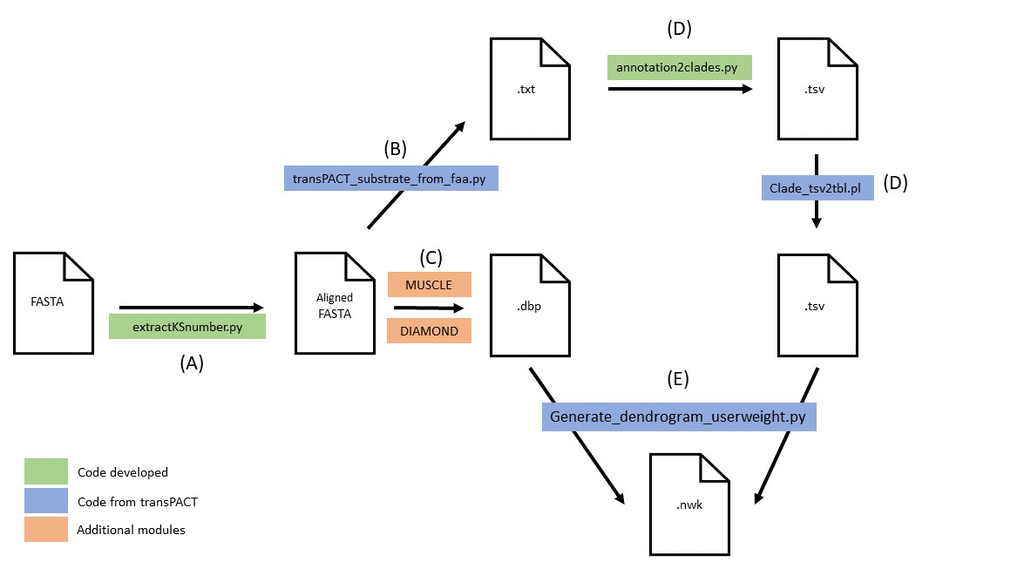

Figure 2: **Overview of the files system of transPACT.**

> (A) Alignment and extraction of the KS numbers  
> (B) KS substrate specificity annotation  
> (C) Generation of an all vs. all table with DIAMOND  
> (D) Processing of the annotation file  
> (E) Dendrogram PKS comparison

### 0. Create a virtual environment with conda with the required packages

It applies for both the VSC and Ubuntu environments.

```python
#cloning the transPACT github repository
git clone https://github.com/AntoineRuzy/transPACT_BDE
```

```python
#go into the newly created directory
cd transPACT
```

```python
#create the environment with all the package dependencies listed in the text file
conda create --name transPACT --file conda_packages.txt
```

```python
#configurate the shell to use the conda commands - NEED TO RESTART YOUR SESSION AFTER RUNNING THIS COMMAND
conda init bash
```

```python
#activate the environment
conda activate transPACT
```

**Conda commands cheat sheet:** https://docs.conda.io/projects/conda/en/4.6.0/_downloads/52a95608c49671267e40c689e0bc00ca/conda-cheatsheet.pdf

### 1. Alignment, extraction of KS numbers and creation of DIAMOND table

First, the 647 KS sequences of reference need to be combined with the query KS sequences in a single FASTA file. It should be noted that a python script is included to transform an aligned FASTA file into an unaligned FASTA file i.e. removing the gaps.

```python
#concatenate two files
#be careful that there should not be an empty line of the end of each concatenated files
cat file1.fasta file2.fasta > file3.fasta
```

Once you have a single FASTA file, the headers of the KS sequences should be modified in order to fit in the following naming format:

> `> <PKS name>|<KS number>`  
> `AIIGISCHVPGAQDHHYFWQNLLNGHESVALLSAEELAAAGIAEELRQNPNYVPARLTIEDKDCFDPAFFNISPRNAAYMDPQARLLLLHSWKAMEDA`  
> `GLAVGDTPETGVFMSATTNFYQLPLGLPVHALQGADGHAAGIQAQGGMIPNTISYHLGLKGPSMFVQSLCSSSLVGLKLACQSLQAGEAKMALIGGA`  
> `NLFAFSRVGHLYEPEMNLSDDGHCRTFDAAATGVVEGEGVCVIVLKKALDAVADRDHIYALLRGISLNNDGADKAGFHAPGVKGQAAAARAVLTATG`  
> `VDPTTIRYVEAHGTGTPSGDAIEVAALSEAYPNGTHRCAIGSLKPNIGNLDTAGGLAGVIKVALGLYHGAIPPQINFNEPAPDIDFTDSPFYVPTQAE`  
> `PWQDDKAPRRAAQNHYSLGGTNVHAIYEA`

```python
#extract KS numbers from initial names and format the FASTA headers
python adaptKS_fastaNames.py #remember to modify the path within the file with nano
```

If the file returns an error, it is very likely that the initial encoding of names was not correct. To check the names that do not contain a correct formatting of the KS numbers, run the following command:

```python
grep -v -E '(_(KS)[0-9]{1,2}_)' annotation_ar_20220331.tsv
```

**VSC implementation**

If you are using a VSC implementation, the below explanations can be followed.

In a typical context, one would possess the sequences of the KS domains of interest stored in a fasta file. Thus, you need to align the query sequences to the reference sequences. To do so, we recommend using [MUSCLE](http://petrov.stanford.edu/software/src/muscle3.6/muscle3.6.html#:~:text=The%20MUSCLE%20algorithm%20is%20delivered%20as%20a%20command-line,to%20us%20older%20people%20as%20a%20DOS%20prompt%29.).

In order to run a job on the VSC, you need to create a .pbs file and send it to the queue. Please refer to this [tutorial](https://docs.vscentrum.be/en/latest/jobs/running_jobs.html#submitting-and-monitoring-a-job) to understand how to submit a job.  
Create a file named `muscle_run.pbs` containing the following lines and then submit your job using the `qsub` command. It should be noted that, by the way, the all vs. all DIAMOND table is generated using the same job script.

```python
#!/usr/bin/env bash

#PBS -l nodes=1:ppn=36
#PBS -l walltime=00:10:00
#PBS -l pmem=5gb
#PBS -A default_project
#PBS -N alignment_full

#modify your path
cd /vsc-hard-mounts/leuven-data/339/vsc33918/transPACT/data/dendogram_test

#load modules
module purge
module load MUSCLE/3.8.31-foss-2018a
module load DIAMOND/0.9.24-foss-2018a

#run muscle to align sequences
#run diamond to create an all vs. all table
clear

#modify the path of the files
muscle -in full_sequences_renamed.fasta -out full_sequences_aln.fasta -maxiters 2
diamond makedb -d all --in full_sequences_aln.fasta
ls
```

**Non-VSC implementation**

If you are not using the VSC, the FASTA file can be aligned using any multiple sequence aligner e.g. [MUSCLE on EMBL](https://www.ebi.ac.uk/Tools/msa/muscle/).  
The all vs. all DIAMOND table can be generated using the aforementioned command lines. However, DIAMOND first needs to be installed.

### 2. Assign functional clade to *trans-AT* PKS's KS domains

> **INPUT:** FASTA file with KS sequences and their corresponding standardized names.  
> **OUTPUT:** Tab-separated text file with names, clade number and clade description.

```python
#run for the single KS domain as an example
#STDOUT (ouput within the console)
python2 transPACT_substrate_from_faa.py example/test.faa

#RECOMMENDED: OUTPUT TO FILE (to save results, needed for further steps)
python2 transPACT_substrate_from_faa.py example/test.faa > clade_annotation.txt
```

### 3. Generate dendrogram visualization for comparison

> **INPUT:** Tab-separated text file in a wide data format with KS numbers as columns, PKS names as rows and substrate annotations as values; FASTA file containing the KS sequences  
> **OUTPUT:** Newick tree file encoding the dendrogram representation ; ITOL annotation file

Suggested weights for distance calculation are JI = 0, DSS = 0.32, AI = 0.68, the same weights that are used in BiG-SCAPE's distance calculation for trans-AT PKS pathways. [[from the transPACT GitHub]](https://github.com/chevrm/transPACT)

#### Set up

```python
#create a dedicated directory
mkdir data/dendrogram_test && cd data/dendrogram_test
```

```python
#copy the python script into that directory
cp ../code/generate_dendrogram_userweights.py ./
```

```python
#list of scripts mandatory to have in your dendrogram folder

annotation2clades.py
cladetsv2tbl.pl
generate_dendrogram_userweights.py
generate_itol.pl
647KS_ar_20220331.fasta
adapt_fastaNames.py

#use the cp command or FileZilla
```

If the permission to copy is denied, it is recommended to use the [FileZilla](https://docs.vscentrum.be/en/latest/access/data_transfer_with_filezilla.html?highlight=filezilla) application to move document within your file system and between your local system and the VSC server.

### Processing of the annotation file

**Generate clades.tsv file**

You start with a file containing the clade annotation in the following format. Such a file can be generated using the *transPACT_substrate_from_faa.py* python script (see Section 2).

> `#Leaf_name Clade_name Clade_desc`  
> `GO485_KS11_00205 Clade_66 double_bonds`  
> `GO485_KS12_00205 Clade_31 eDB`  
> `GO485_KS13_00210 Clade_5 shifted_double_bonds`  
> `GO485_KS1_00250 Clade_2 amino acids`  
> `GO485_KS2_00250 Clade_62 eDB`

Note the standardized names!

To extract the KS sequence names, the KS numbers and the clade numbers, the following python script has been developed (accesible on the aforementioned [repository](https://github.com/AntoineRuzy/transPACTonVSC)).

```python
python2 annotation2clades.py
#this script creates two files: full_annotation.tsv and full_annotation.clades.tsv
```

**Generate annotation.tsv file**

```python
perl cladetsv2tbl.pl > file.annotationtable.tsv
#change the path of the clades.tsv file in the perl script (use the nano command)
#Use the perl script from the dendrogram20190514 directory, it is the correct one
```

If you see a special character (namely *^M* ) called the carriage return in the annotationtable.tsv file, then run the following command to get rid of it:

```python
sed -i -e "s/\r//g" file.annotationtable.tsv #it overwrites the file
```

### Generate the Newick tree file

```python
#use nano to modify the path of the input files: annotation.tsv and full.dbp at line 576
nano generate_dendrogram_userweights.py
```

```python
#run the python script with the weights used in distance calculation
python2 generate_dendrogram_userweights.py 0 0.32 0.68
```

The `.nwk`can then be uploaded on ITOL for visualization.

### Generate ITOL annotation file

In order to generate an ITOL annotation file for KS domains, you will need three files and a Perl script:

- an `annotationtable.tsv` file: clade assignment per KS domain for each PKS
- a full clade annotation text file: clade assignment with its description for each KS domains
- a `upgma.nwk` file: dendrogram architecture of the KS sequences
- a perl script available at `data/dendrogram20200320/generate_itol.pl`

```python
perl generate_itol.pl > annotation_dom.txt
```

The `annotation_dom.txt` can then be added as an annotation file in ITOL alongside with the `.nwk` tree file.

Note that ITOL annotation file is of the following structure:

> `PKS,TOTAL LENGTH, EL|START|END|COLOR#|CLADE NUMBER, EL|...`

Up to Contents  
Down to Output illustration

### 4. Genome mining approach - phylogenetic assessment of the KS sequences of publicly available PKS's

**ETL: Extract, Transform and Load**

The latest version (29/03/2022) of the antismash clusterblast database is available through the following link: https://dl.secondarymetabolites.org/releases/clusterblast/clusterblast_20201113.tar.xz

It loads a .tar.xz file. Transfer that file on your global transPACT directory on the VSC (using FileZilla e.g.). To extract such a file, apply the following commands:

```python
tar –xvzf clusterblast_20201113.tar.xz –C /home/user/destination
# -C option enables you to extract the content in a directory of your choice
```

In order to gather KS domain sequences, you can either manually copy paste their sequences from a data base (e.g. antismash > copy to clipboard) or you can extract the sequences of the KS domain from protein sequences. The second option is described in the following lines.

Profile Hidden Markov Models are probabilistic models used to predict protein domains as they capture position-specific information about how conserved each amino acid is in each column of the alignment.

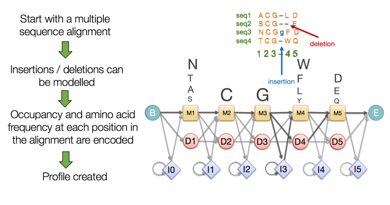

Source: [EMBL-EBI training](https://www.ebi.ac.uk/training/online/courses/pfam-creating-protein-families/what-are-profile-hidden-markov-models-hmms/)

Practically, we use the *extract_tKS.py* python script developed by Marnix Medema, that implements the aforementioned probabilistic model.

Input files:

- HMM profiled for KS sequences: PKS.hmm
- HMM profiled for AT sequences: AT.hmm
- Multiple Sequence Alignment of your protein sequences (.afa file)

Both .hmm files are available on the BDE GitHub (under *genome_mining_approach* folder).

Output file:

- FASTA file of the extracted KS sequences

Before running the script, we need to load the HMMER module.

```python
module purge #good practices to purge before creating a module environment

module spider HMMER #to grab the actual version of the HMMER module to load
module load ...

module save HMMER_env
#'module savelist' to check your saved environment
```

From the whole clusterblast database, the HMM profile model identified 17,027 trans-AT KS sequences (on the date of May 02, 2022). The next step is now to predict the substrate specific for each predicted KS modules. However, let's first assess the accuracy of the HMM profile model.

My idea to format the fasta file of the clusterblast database is to use the following metrics as unique IDs:

- RefSeq ID: NZ_xxxx => unique ID for the bacterial species
- PKS positional ID: cXXX_XXX => unique ID for the PKS
- Module positional ID: XXX-XXX => unique ID for a module within the PKS
- KS number: KSx => unique ID for a KS given a specific PKS

Thus, a combination of the RefSeq ID, the PKS positional ID and the module positional ID yields an unique identifier for each KS sequence. Its KS number will be added by default by the pattern search.

# Output illustration

Loading the Newick tree file and its corresponding domain file in ITOL sould yield the following cladograms, either in circular or rectangular representations.

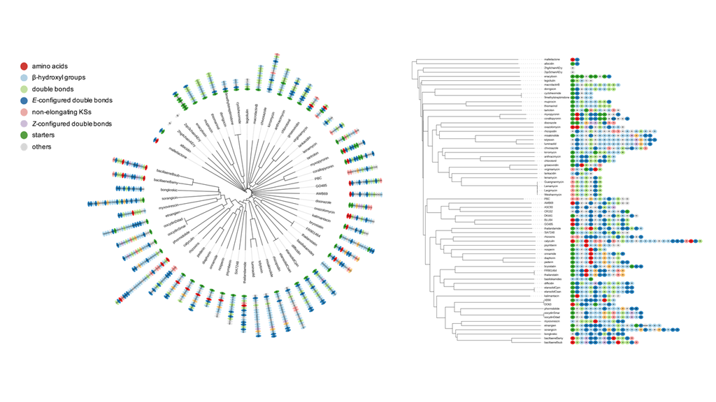

Figure 3: **Circular and rectangular cladogram representation of module blocks conservation in ITOL.**  
Colors represent classes of KS clades that correlate with polyketide motifs i.e. KS specificity for the incoming subrate.

*Cladograms can be accessed via* https://itol.embl.de/export/62205120139364271650624817.

Up to Contents